# W3cubDocs

/scikit-learn

# sklearn.metrics.adjusted_rand_score

**`sklearn.metrics.adjusted_rand_score(labels_true, labels_pred)` [[source]](https://github.com/scikit-learn/scikit-learn/blob/bac89c2/sklearn/metrics/cluster/supervised.py#L138)**

Rand index adjusted for chance.

The Rand Index computes a similarity measure between two clusterings by considering all pairs of samples and counting pairs that are assigned in the same or different clusters in the predicted and true clusterings.

The raw RI score is then “adjusted for chance” into the ARI score using the following scheme:

```
ARI = (RI - Expected_RI) / (max(RI) - Expected_RI)
```

The adjusted Rand index is thus ensured to have a value close to 0.0 for random labeling independently of the number of clusters and samples and exactly 1.0 when the clusterings are identical (up to a permutation).

ARI is a symmetric measure:

```
adjusted_rand_score(a, b) == adjusted_rand_score(b, a)
```

Read more in the User Guide.

| Parameters: | **`labels_true : int array, shape = [n_samples]`** Ground truth class labels to be used as a reference **`labels_pred : array, shape = [n_samples]`** Cluster labels to evaluate |
| --- | --- |
| Returns: | **`ari : float`** Similarity score between -1.0 and 1.0. Random labelings have an ARI close to 0.0. 1.0 stands for perfect match. |

See also

**`adjusted_mutual_info_score`**

Adjusted Mutual Information

#### References

| [Hubert1985] | `L. Hubert and P. Arabie, Comparing Partitions, Journal of Classification 1985` http://link.springer.com/article/10.1007%2FBF01908075 |
| --- | --- |

| [wk] | https://en.wikipedia.org/wiki/Rand_index#Adjusted_Rand_index |
| --- | --- |

#### Examples

```
>>> from sklearn.metrics.cluster import adjusted_rand_score
>>> adjusted_rand_score([0, 0, 1, 1], [0, 0, 1, 1])
1.0
>>> adjusted_rand_score([0, 0, 1, 1], [1, 1, 0, 0])
1.0
```

Labelings that assign all classes members to the same clusters are complete be not always pure, hence penalized:

```
>>> adjusted_rand_score([0, 0, 1, 2], [0, 0, 1, 1])
0.57...
```

ARI is symmetric, so labelings that have pure clusters with members coming from the same classes but unnecessary splits are penalized:

```
>>> adjusted_rand_score([0, 0, 1, 1], [0, 0, 1, 2])
0.57...
```

If classes members are completely split across different clusters, the assignment is totally incomplete, hence the ARI is very low:

```
>>> adjusted_rand_score([0, 0, 0, 0], [0, 1, 2, 3])
0.0
```

## Examples using `sklearn.metrics.adjusted_rand_score`

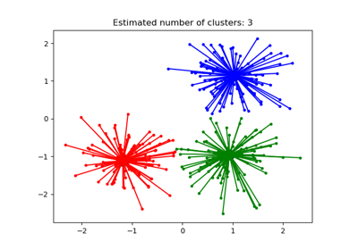

Demo of affinity propagation clustering algorithm

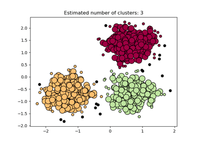

Demo of DBSCAN clustering algorithm

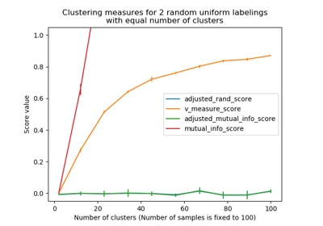

Adjustment for chance in clustering performance evaluation

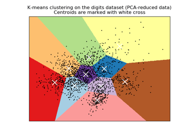

A demo of K-Means clustering on the handwritten digits data

© 2007–2018 The scikit-learn developers  
Licensed under the 3-clause BSD License.  
http://scikit-learn.org/stable/modules/generated/sklearn.metrics.adjusted_rand_score.html